# Risk Factor Analysis

## Outcome Variable

**Outcome Variable:** pers_wast

## Predictor Variables

**Intervention Variable:** gagebrth

**Adjustment Set:**

unadjusted

## Stratifying Variables

The analysis was stratified on these variable(s):

- agecat
- studyid
- country

## Data Summary

| agecat | studyid | country | gagebrth | pers_wast | n_cell | n |
| --- | --- | --- | --- | --- | --- | --- |
| 0-24 months | ki1000108-CMC-V-BCS-2002 | INDIA | Full or late term | 0 | 201 | 351 |
| 0-24 months | ki1000108-CMC-V-BCS-2002 | INDIA | Full or late term | 1 | 14 | 351 |
| 0-24 months | ki1000108-CMC-V-BCS-2002 | INDIA | Preterm | 0 | 49 | 351 |
| 0-24 months | ki1000108-CMC-V-BCS-2002 | INDIA | Preterm | 1 | 3 | 351 |
| 0-24 months | ki1000108-CMC-V-BCS-2002 | INDIA | Early term | 0 | 81 | 351 |
| 0-24 months | ki1000108-CMC-V-BCS-2002 | INDIA | Early term | 1 | 3 | 351 |
| 0-24 months | ki1000108-IRC | INDIA | Full or late term | 0 | 225 | 390 |
| 0-24 months | ki1000108-IRC | INDIA | Full or late term | 1 | 25 | 390 |
| 0-24 months | ki1000108-IRC | INDIA | Preterm | 0 | 34 | 390 |
| 0-24 months | ki1000108-IRC | INDIA | Preterm | 1 | 8 | 390 |
| 0-24 months | ki1000108-IRC | INDIA | Early term | 0 | 85 | 390 |
| 0-24 months | ki1000108-IRC | INDIA | Early term | 1 | 13 | 390 |
| 0-24 months | ki1000109-EE | PAKISTAN | Full or late term | 0 | 16 | 377 |
| 0-24 months | ki1000109-EE | PAKISTAN | Full or late term | 1 | 1 | 377 |
| 0-24 months | ki1000109-EE | PAKISTAN | Preterm | 0 | 274 | 377 |
| 0-24 months | ki1000109-EE | PAKISTAN | Preterm | 1 | 27 | 377 |
| 0-24 months | ki1000109-EE | PAKISTAN | Early term | 0 | 54 | 377 |
| 0-24 months | ki1000109-EE | PAKISTAN | Early term | 1 | 5 | 377 |
| 0-24 months | ki1017093c-NIH-Crypto | BANGLADESH | Full or late term | 0 | 156 | 730 |
| 0-24 months | ki1017093c-NIH-Crypto | BANGLADESH | Full or late term | 1 | 2 | 730 |
| 0-24 months | ki1017093c-NIH-Crypto | BANGLADESH | Preterm | 0 | 241 | 730 |
| 0-24 months | ki1017093c-NIH-Crypto | BANGLADESH | Preterm | 1 | 14 | 730 |
| 0-24 months | ki1017093c-NIH-Crypto | BANGLADESH | Early term | 0 | 307 | 730 |
| 0-24 months | ki1017093c-NIH-Crypto | BANGLADESH | Early term | 1 | 10 | 730 |
| 0-24 months | ki1066203-TanzaniaChild2 | TANZANIA, UNITED REPUBLIC OF | Full or late term | 0 | 1212 | 2035 |
| 0-24 months | ki1066203-TanzaniaChild2 | TANZANIA, UNITED REPUBLIC OF | Full or late term | 1 | 33 | 2035 |
| 0-24 months | ki1066203-TanzaniaChild2 | TANZANIA, UNITED REPUBLIC OF | Preterm | 0 | 306 | 2035 |
| 0-24 months | ki1066203-TanzaniaChild2 | TANZANIA, UNITED REPUBLIC OF | Preterm | 1 | 11 | 2035 |
| 0-24 months | ki1066203-TanzaniaChild2 | TANZANIA, UNITED REPUBLIC OF | Early term | 0 | 462 | 2035 |
| 0-24 months | ki1066203-TanzaniaChild2 | TANZANIA, UNITED REPUBLIC OF | Early term | 1 | 11 | 2035 |

[output cut: 156 more lines]

The following strata were considered:

- agecat: 0-24 months, studyid: ki1000108-CMC-V-BCS-2002, country: INDIA
- agecat: 0-24 months, studyid: ki1000108-IRC, country: INDIA
- agecat: 0-24 months, studyid: ki1000109-EE, country: PAKISTAN
- agecat: 0-24 months, studyid: ki1017093c-NIH-Crypto, country: BANGLADESH
- agecat: 0-24 months, studyid: ki1066203-TanzaniaChild2, country: TANZANIA, UNITED REPUBLIC OF
- agecat: 0-24 months, studyid: ki1101329-Keneba, country: GAMBIA
- agecat: 0-24 months, studyid: ki1119695-PROBIT, country: BELARUS
- agecat: 0-24 months, studyid: ki1135781-COHORTS, country: GUATEMALA
- agecat: 0-24 months, studyid: ki1135781-COHORTS, country: INDIA
- agecat: 0-24 months, studyid: ki1135781-COHORTS, country: PHILIPPINES
- agecat: 0-24 months, studyid: kiGH5241-JiVitA-3, country: BANGLADESH
- agecat: 0-6 months, studyid: ki1000108-CMC-V-BCS-2002, country: INDIA
- agecat: 0-6 months, studyid: ki1000108-IRC, country: INDIA
- agecat: 0-6 months, studyid: ki1000109-EE, country: PAKISTAN
- agecat: 0-6 months, studyid: ki1017093c-NIH-Crypto, country: BANGLADESH
- agecat: 0-6 months, studyid: ki1066203-TanzaniaChild2, country: TANZANIA, UNITED REPUBLIC OF
- agecat: 0-6 months, studyid: ki1101329-Keneba, country: GAMBIA
- agecat: 0-6 months, studyid: ki1119695-PROBIT, country: BELARUS
- agecat: 0-6 months, studyid: ki1135781-COHORTS, country: PHILIPPINES
- agecat: 0-6 months, studyid: kiGH5241-JiVitA-3, country: BANGLADESH
- agecat: 6-24 months, studyid: ki1000108-CMC-V-BCS-2002, country: INDIA
- agecat: 6-24 months, studyid: ki1000108-IRC, country: INDIA
- agecat: 6-24 months, studyid: ki1000109-EE, country: PAKISTAN
- agecat: 6-24 months, studyid: ki1017093c-NIH-Crypto, country: BANGLADESH
- agecat: 6-24 months, studyid: ki1066203-TanzaniaChild2, country: TANZANIA, UNITED REPUBLIC OF
- agecat: 6-24 months, studyid: ki1101329-Keneba, country: GAMBIA
- agecat: 6-24 months, studyid: ki1119695-PROBIT, country: BELARUS
- agecat: 6-24 months, studyid: ki1135781-COHORTS, country: GUATEMALA
- agecat: 6-24 months, studyid: ki1135781-COHORTS, country: INDIA
- agecat: 6-24 months, studyid: ki1135781-COHORTS, country: PHILIPPINES
- agecat: 6-24 months, studyid: kiGH5241-JiVitA-3, country: BANGLADESH

### Dropped Strata

Some strata were dropped due to rare outcomes:

- agecat: 0-24 months, studyid: ki1000108-CMC-V-BCS-2002, country: INDIA
- agecat: 0-24 months, studyid: ki1000109-EE, country: PAKISTAN
- agecat: 0-24 months, studyid: ki1017093c-NIH-Crypto, country: BANGLADESH
- agecat: 0-6 months, studyid: ki1000109-EE, country: PAKISTAN
- agecat: 0-6 months, studyid: ki1017093c-NIH-Crypto, country: BANGLADESH
- agecat: 0-6 months, studyid: kiGH5241-JiVitA-3, country: BANGLADESH
- agecat: 6-24 months, studyid: ki1000108-CMC-V-BCS-2002, country: INDIA
- agecat: 6-24 months, studyid: ki1000109-EE, country: PAKISTAN
- agecat: 6-24 months, studyid: ki1017093c-NIH-Crypto, country: BANGLADESH

## Methods Detail

We’re interested in the causal parameters $E[Y_a]$ for all values of $a \in \mathcal{A}$. These parameters represent the mean outcome if, possibly contrary to fact, we intervened to set all units to have $A=a$. Under the randomization and positivity assumptions, these are identified by the statistical parameters $\psi_a=E_W[E_{Y|A,W}(Y|A=a,W)]$. In addition, we’re interested in the mean of $Y$, $E[Y]$ under no intervention (the observed mean). We will estimate these parameters by using SuperLearner to fit the relevant likelihood factors – $E_{Y|A,W}(Y|A=a,W)$ and $p(A=a|W)$, and then updating our likelihood fit using a joint TMLE.

For unadjusted analyses ($W=\{\}$), initial likelihoods were estimated using Lrnr_glm to estimate the simple $E(Y|A)$ and Lrnr_mean to estimate $p(A)$. For adjusted analyses, a small library containing Lrnr_glmnet, Lrnr_xgboost, and Lrnr_mean was used.

Having estimated these parameters, we will then use the delta method to estimate relative risks and attributable risks relative to a prespecified baseline level of $A$.

# Results Detail

## Results Plots

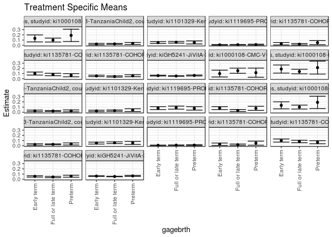

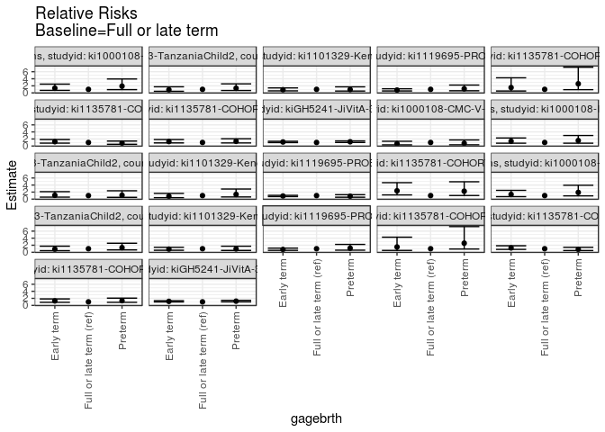

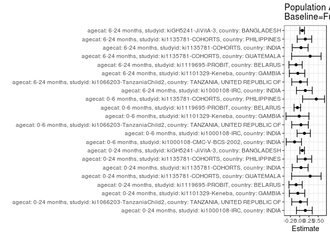

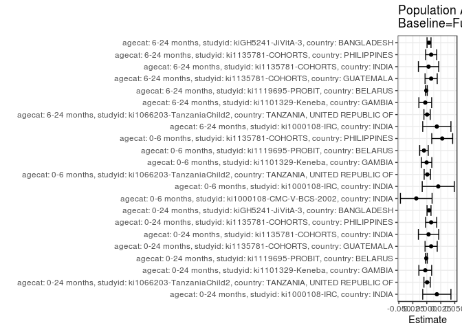

## Results Table

### Parameter: TSM

| agecat | studyid | country | intervention_level | baseline_level | estimate | ci_lower | ci_upper |
| --- | --- | --- | --- | --- | --- | --- | --- |
| 0-24 months | ki1000108-IRC | INDIA | Full or late term | NA | 0.1000000 | 0.0627645 | 0.1372355 |
| 0-24 months | ki1000108-IRC | INDIA | Preterm | NA | 0.1904762 | 0.0715668 | 0.3093856 |
| 0-24 months | ki1000108-IRC | INDIA | Early term | NA | 0.1326531 | 0.0654100 | 0.1998961 |
| 0-24 months | ki1066203-TanzaniaChild2 | TANZANIA, UNITED REPUBLIC OF | Full or late term | NA | 0.0265060 | 0.0175810 | 0.0354310 |
| 0-24 months | ki1066203-TanzaniaChild2 | TANZANIA, UNITED REPUBLIC OF | Preterm | NA | 0.0347003 | 0.0145481 | 0.0548525 |
| 0-24 months | ki1066203-TanzaniaChild2 | TANZANIA, UNITED REPUBLIC OF | Early term | NA | 0.0232558 | 0.0096702 | 0.0368415 |
| 0-24 months | ki1101329-Keneba | GAMBIA | Full or late term | NA | 0.0578406 | 0.0414319 | 0.0742493 |
| 0-24 months | ki1101329-Keneba | GAMBIA | Preterm | NA | 0.0543933 | 0.0256316 | 0.0831550 |
| 0-24 months | ki1101329-Keneba | GAMBIA | Early term | NA | 0.0516014 | 0.0333059 | 0.0698969 |
| 0-24 months | ki1119695-PROBIT | BELARUS | Full or late term | NA | 0.0105052 | 0.0058392 | 0.0151712 |
| 0-24 months | ki1119695-PROBIT | BELARUS | Preterm | NA | 0.0120690 | 0.0030561 | 0.0210818 |
| 0-24 months | ki1119695-PROBIT | BELARUS | Early term | NA | 0.0083676 | 0.0038455 | 0.0128898 |
| 0-24 months | ki1135781-COHORTS | GUATEMALA | Full or late term | NA | 0.0195599 | 0.0061299 | 0.0329899 |
| 0-24 months | ki1135781-COHORTS | GUATEMALA | Preterm | NA | 0.0504202 | 0.0110797 | 0.0897606 |
| 0-24 months | ki1135781-COHORTS | GUATEMALA | Early term | NA | 0.0294118 | 0.0062107 | 0.0526128 |
| 0-24 months | ki1135781-COHORTS | INDIA | Full or late term | NA | 0.0820313 | 0.0582519 | 0.1058106 |
| 0-24 months | ki1135781-COHORTS | INDIA | Preterm | NA | 0.0676692 | 0.0374717 | 0.0978667 |
| 0-24 months | ki1135781-COHORTS | INDIA | Early term | NA | 0.1004902 | 0.0713048 | 0.1296756 |
| 0-24 months | ki1135781-COHORTS | PHILIPPINES | Full or late term | NA | 0.0434783 | 0.0313193 | 0.0556372 |
| 0-24 months | ki1135781-COHORTS | PHILIPPINES | Preterm | NA | 0.0582192 | 0.0392247 | 0.0772137 |
| 0-24 months | ki1135781-COHORTS | PHILIPPINES | Early term | NA | 0.0551601 | 0.0418116 | 0.0685087 |
| 0-24 months | kiGH5241-JiVitA-3 | BANGLADESH | Full or late term | NA | 0.0530368 | 0.0475886 | 0.0584850 |
| 0-24 months | kiGH5241-JiVitA-3 | BANGLADESH | Preterm | NA | 0.0635625 | 0.0541104 | 0.0730145 |
| 0-24 months | kiGH5241-JiVitA-3 | BANGLADESH | Early term | NA | 0.0605769 | 0.0529049 | 0.0682489 |
| 0-6 months | ki1000108-CMC-V-BCS-2002 | INDIA | Full or late term | NA | 0.1553398 | 0.1058014 | 0.2048782 |
| 0-6 months | ki1000108-CMC-V-BCS-2002 | INDIA | Preterm | NA | 0.1176471 | 0.0290906 | 0.2062035 |
| 0-6 months | ki1000108-CMC-V-BCS-2002 | INDIA | Early term | NA | 0.1000000 | 0.0341631 | 0.1658369 |
| 0-6 months | ki1000108-IRC | INDIA | Full or late term | NA | 0.1387755 | 0.0954297 | 0.1821213 |
| 0-6 months | ki1000108-IRC | INDIA | Preterm | NA | 0.2142857 | 0.0900289 | 0.3385425 |
| 0-6 months | ki1000108-IRC | INDIA | Early term | NA | 0.1875000 | 0.1093206 | 0.2656794 |
| 0-6 months | ki1066203-TanzaniaChild2 | TANZANIA, UNITED REPUBLIC OF | Full or late term | NA | 0.0244519 | 0.0156597 | 0.0332442 |
| 0-6 months | ki1066203-TanzaniaChild2 | TANZANIA, UNITED REPUBLIC OF | Preterm | NA | 0.0268456 | 0.0084896 | 0.0452017 |
| 0-6 months | ki1066203-TanzaniaChild2 | TANZANIA, UNITED REPUBLIC OF | Early term | NA | 0.0266667 | 0.0117775 | 0.0415558 |
| 0-6 months | ki1101329-Keneba | GAMBIA | Full or late term | NA | 0.0309278 | 0.0179016 | 0.0439541 |
| 0-6 months | ki1101329-Keneba | GAMBIA | Preterm | NA | 0.0412844 | 0.0148657 | 0.0677031 |
| 0-6 months | ki1101329-Keneba | GAMBIA | Early term | NA | 0.0254403 | 0.0117832 | 0.0390974 |
| 0-6 months | ki1119695-PROBIT | BELARUS | Full or late term | NA | 0.0896770 | 0.0600269 | 0.1193271 |
| 0-6 months | ki1119695-PROBIT | BELARUS | Preterm | NA | 0.0743982 | 0.0408996 | 0.1078969 |
| 0-6 months | ki1119695-PROBIT | BELARUS | Early term | NA | 0.0796489 | 0.0511745 | 0.1081233 |
| 0-6 months | ki1135781-COHORTS | PHILIPPINES | Full or late term | NA | 0.0337423 | 0.0141300 | 0.0533547 |
| 0-6 months | ki1135781-COHORTS | PHILIPPINES | Preterm | NA | 0.0760234 | 0.0362758 | 0.1157709 |
| 0-6 months | ki1135781-COHORTS | PHILIPPINES | Early term | NA | 0.0797721 | 0.0514109 | 0.1081332 |
| 6-24 months | ki1000108-IRC | INDIA | Full or late term | NA | 0.1000000 | 0.0627645 | 0.1372355 |
| 6-24 months | ki1000108-IRC | INDIA | Preterm | NA | 0.1904762 | 0.0715668 | 0.3093856 |
| 6-24 months | ki1000108-IRC | INDIA | Early term | NA | 0.1326531 | 0.0654100 | 0.1998961 |
| 6-24 months | ki1066203-TanzaniaChild2 | TANZANIA, UNITED REPUBLIC OF | Full or late term | NA | 0.0265060 | 0.0175810 | 0.0354310 |
| 6-24 months | ki1066203-TanzaniaChild2 | TANZANIA, UNITED REPUBLIC OF | Preterm | NA | 0.0347003 | 0.0145481 | 0.0548525 |
| 6-24 months | ki1066203-TanzaniaChild2 | TANZANIA, UNITED REPUBLIC OF | Early term | NA | 0.0232558 | 0.0096702 | 0.0368415 |
| 6-24 months | ki1101329-Keneba | GAMBIA | Full or late term | NA | 0.0578406 | 0.0414319 | 0.0742493 |
| 6-24 months | ki1101329-Keneba | GAMBIA | Preterm | NA | 0.0543933 | 0.0256316 | 0.0831550 |
| 6-24 months | ki1101329-Keneba | GAMBIA | Early term | NA | 0.0516014 | 0.0333059 | 0.0698969 |
| 6-24 months | ki1119695-PROBIT | BELARUS | Full or late term | NA | 0.0105052 | 0.0058392 | 0.0151712 |
| 6-24 months | ki1119695-PROBIT | BELARUS | Preterm | NA | 0.0120690 | 0.0030561 | 0.0210818 |
| 6-24 months | ki1119695-PROBIT | BELARUS | Early term | NA | 0.0083676 | 0.0038455 | 0.0128898 |
| 6-24 months | ki1135781-COHORTS | GUATEMALA | Full or late term | NA | 0.0195599 | 0.0061299 | 0.0329899 |
| 6-24 months | ki1135781-COHORTS | GUATEMALA | Preterm | NA | 0.0504202 | 0.0110797 | 0.0897606 |
| 6-24 months | ki1135781-COHORTS | GUATEMALA | Early term | NA | 0.0294118 | 0.0062107 | 0.0526128 |
| 6-24 months | ki1135781-COHORTS | INDIA | Full or late term | NA | 0.0820313 | 0.0582519 | 0.1058106 |
| 6-24 months | ki1135781-COHORTS | INDIA | Preterm | NA | 0.0676692 | 0.0374717 | 0.0978667 |
| 6-24 months | ki1135781-COHORTS | INDIA | Early term | NA | 0.1004902 | 0.0713048 | 0.1296756 |
| 6-24 months | ki1135781-COHORTS | PHILIPPINES | Full or late term | NA | 0.0434783 | 0.0313193 | 0.0556372 |
| 6-24 months | ki1135781-COHORTS | PHILIPPINES | Preterm | NA | 0.0582192 | 0.0392247 | 0.0772137 |
| 6-24 months | ki1135781-COHORTS | PHILIPPINES | Early term | NA | 0.0551601 | 0.0418116 | 0.0685087 |
| 6-24 months | kiGH5241-JiVitA-3 | BANGLADESH | Full or late term | NA | 0.0530368 | 0.0475886 | 0.0584850 |
| 6-24 months | kiGH5241-JiVitA-3 | BANGLADESH | Preterm | NA | 0.0635625 | 0.0541104 | 0.0730145 |
| 6-24 months | kiGH5241-JiVitA-3 | BANGLADESH | Early term | NA | 0.0605769 | 0.0529049 | 0.0682489 |

### Parameter: E(Y)

| agecat | studyid | country | intervention_level | baseline_level | estimate | ci_lower | ci_upper |
| --- | --- | --- | --- | --- | --- | --- | --- |
| 0-24 months | ki1000108-IRC | INDIA | NA | NA | 0.1179487 | 0.0858959 | 0.1500016 |
| 0-24 months | ki1066203-TanzaniaChild2 | TANZANIA, UNITED REPUBLIC OF | NA | NA | 0.0270270 | 0.0199797 | 0.0340743 |
| 0-24 months | ki1101329-Keneba | GAMBIA | NA | NA | 0.0550982 | 0.0438403 | 0.0663560 |
| 0-24 months | ki1119695-PROBIT | BELARUS | NA | NA | 0.0095893 | 0.0052864 | 0.0138922 |
| 0-24 months | ki1135781-COHORTS | GUATEMALA | NA | NA | 0.0273224 | 0.0155047 | 0.0391401 |
| 0-24 months | ki1135781-COHORTS | INDIA | NA | NA | 0.0851602 | 0.0692682 | 0.1010522 |
| 0-24 months | ki1135781-COHORTS | PHILIPPINES | NA | NA | 0.0512729 | 0.0430860 | 0.0594597 |
| 0-24 months | kiGH5241-JiVitA-3 | BANGLADESH | NA | NA | 0.0570138 | 0.0528460 | 0.0611815 |
| 0-6 months | ki1000108-CMC-V-BCS-2002 | INDIA | NA | NA | 0.1364985 | 0.0997894 | 0.1732076 |
| 0-6 months | ki1000108-IRC | INDIA | NA | NA | 0.1592689 | 0.1225736 | 0.1959642 |
| 0-6 months | ki1066203-TanzaniaChild2 | TANZANIA, UNITED REPUBLIC OF | NA | NA | 0.0253361 | 0.0183307 | 0.0323414 |
| 0-6 months | ki1101329-Keneba | GAMBIA | NA | NA | 0.0305398 | 0.0215490 | 0.0395306 |
| 0-6 months | ki1119695-PROBIT | BELARUS | NA | NA | 0.0846069 | 0.0570929 | 0.1121208 |
| 0-6 months | ki1135781-COHORTS | PHILIPPINES | NA | NA | 0.0613208 | 0.0451635 | 0.0774781 |
| 6-24 months | ki1000108-IRC | INDIA | NA | NA | 0.1179487 | 0.0858959 | 0.1500016 |
| 6-24 months | ki1066203-TanzaniaChild2 | TANZANIA, UNITED REPUBLIC OF | NA | NA | 0.0270270 | 0.0199797 | 0.0340743 |
| 6-24 months | ki1101329-Keneba | GAMBIA | NA | NA | 0.0550982 | 0.0438403 | 0.0663560 |
| 6-24 months | ki1119695-PROBIT | BELARUS | NA | NA | 0.0095893 | 0.0052864 | 0.0138922 |
| 6-24 months | ki1135781-COHORTS | GUATEMALA | NA | NA | 0.0273224 | 0.0155047 | 0.0391401 |
| 6-24 months | ki1135781-COHORTS | INDIA | NA | NA | 0.0851602 | 0.0692682 | 0.1010522 |
| 6-24 months | ki1135781-COHORTS | PHILIPPINES | NA | NA | 0.0512729 | 0.0430860 | 0.0594597 |
| 6-24 months | kiGH5241-JiVitA-3 | BANGLADESH | NA | NA | 0.0570138 | 0.0528460 | 0.0611815 |

### Parameter: RR

| agecat | studyid | country | intervention_level | baseline_level | estimate | ci_lower | ci_upper |
| --- | --- | --- | --- | --- | --- | --- | --- |
| 0-24 months | ki1000108-IRC | INDIA | Full or late term | Full or late term | 1.0000000 | 1.0000000 | 1.000000 |
| 0-24 months | ki1000108-IRC | INDIA | Preterm | Full or late term | 1.9047619 | 0.9207828 | 3.940254 |
| 0-24 months | ki1000108-IRC | INDIA | Early term | Full or late term | 1.3265306 | 0.7072263 | 2.488148 |
| 0-24 months | ki1066203-TanzaniaChild2 | TANZANIA, UNITED REPUBLIC OF | Full or late term | Full or late term | 1.0000000 | 1.0000000 | 1.000000 |
| 0-24 months | ki1066203-TanzaniaChild2 | TANZANIA, UNITED REPUBLIC OF | Preterm | Full or late term | 1.3091483 | 0.6690294 | 2.561725 |
| 0-24 months | ki1066203-TanzaniaChild2 | TANZANIA, UNITED REPUBLIC OF | Early term | Full or late term | 0.8773784 | 0.4470465 | 1.721953 |
| 0-24 months | ki1101329-Keneba | GAMBIA | Full or late term | Full or late term | 1.0000000 | 1.0000000 | 1.000000 |
| 0-24 months | ki1101329-Keneba | GAMBIA | Preterm | Full or late term | 0.9403998 | 0.5160680 | 1.713634 |
| 0-24 months | ki1101329-Keneba | GAMBIA | Early term | Full or late term | 0.8921313 | 0.5665326 | 1.404859 |
| 0-24 months | ki1119695-PROBIT | BELARUS | Full or late term | Full or late term | 1.0000000 | 1.0000000 | 1.000000 |
| 0-24 months | ki1119695-PROBIT | BELARUS | Preterm | Full or late term | 1.1488570 | 0.5931471 | 2.225203 |
| 0-24 months | ki1119695-PROBIT | BELARUS | Early term | Full or late term | 0.7965246 | 0.5427623 | 1.168931 |
| 0-24 months | ki1135781-COHORTS | GUATEMALA | Full or late term | Full or late term | 1.0000000 | 1.0000000 | 1.000000 |
| 0-24 months | ki1135781-COHORTS | GUATEMALA | Preterm | Full or late term | 2.5777311 | 0.9117126 | 7.288149 |
| 0-24 months | ki1135781-COHORTS | GUATEMALA | Early term | Full or late term | 1.5036765 | 0.5284081 | 4.278971 |
| 0-24 months | ki1135781-COHORTS | INDIA | Full or late term | Full or late term | 1.0000000 | 1.0000000 | 1.000000 |
| 0-24 months | ki1135781-COHORTS | INDIA | Preterm | Full or late term | 0.8249194 | 0.4845141 | 1.404483 |
| 0-24 months | ki1135781-COHORTS | INDIA | Early term | Full or late term | 1.2250233 | 0.8127084 | 1.846520 |
| 0-24 months | ki1135781-COHORTS | PHILIPPINES | Full or late term | Full or late term | 1.0000000 | 1.0000000 | 1.000000 |
| 0-24 months | ki1135781-COHORTS | PHILIPPINES | Preterm | Full or late term | 1.3390410 | 0.8713097 | 2.057857 |
| 0-24 months | ki1135781-COHORTS | PHILIPPINES | Early term | Full or late term | 1.2686832 | 0.8764771 | 1.836394 |
| 0-24 months | kiGH5241-JiVitA-3 | BANGLADESH | Full or late term | Full or late term | 1.0000000 | 1.0000000 | 1.000000 |
| 0-24 months | kiGH5241-JiVitA-3 | BANGLADESH | Preterm | Full or late term | 1.1984598 | 1.0006349 | 1.435395 |
| 0-24 months | kiGH5241-JiVitA-3 | BANGLADESH | Early term | Full or late term | 1.1421681 | 0.9778412 | 1.334110 |
| 0-6 months | ki1000108-CMC-V-BCS-2002 | INDIA | Full or late term | Full or late term | 1.0000000 | 1.0000000 | 1.000000 |
| 0-6 months | ki1000108-CMC-V-BCS-2002 | INDIA | Preterm | Full or late term | 0.7573529 | 0.3343982 | 1.715271 |
| 0-6 months | ki1000108-CMC-V-BCS-2002 | INDIA | Early term | Full or late term | 0.6437500 | 0.3097517 | 1.337891 |
| 0-6 months | ki1000108-IRC | INDIA | Full or late term | Full or late term | 1.0000000 | 1.0000000 | 1.000000 |
| 0-6 months | ki1000108-IRC | INDIA | Preterm | Full or late term | 1.5441176 | 0.7991678 | 2.983478 |
| 0-6 months | ki1000108-IRC | INDIA | Early term | Full or late term | 1.3511029 | 0.8024776 | 2.274804 |
| 0-6 months | ki1066203-TanzaniaChild2 | TANZANIA, UNITED REPUBLIC OF | Full or late term | Full or late term | 1.0000000 | 1.0000000 | 1.000000 |
| 0-6 months | ki1066203-TanzaniaChild2 | TANZANIA, UNITED REPUBLIC OF | Preterm | Full or late term | 1.0978940 | 0.5070474 | 2.377236 |
| 0-6 months | ki1066203-TanzaniaChild2 | TANZANIA, UNITED REPUBLIC OF | Early term | Full or late term | 1.0905747 | 0.5613548 | 2.118719 |
| 0-6 months | ki1101329-Keneba | GAMBIA | Full or late term | Full or late term | 1.0000000 | 1.0000000 | 1.000000 |
| 0-6 months | ki1101329-Keneba | GAMBIA | Preterm | Full or late term | 1.3348624 | 0.6204803 | 2.871739 |
| 0-6 months | ki1101329-Keneba | GAMBIA | Early term | Full or late term | 0.8225701 | 0.4157567 | 1.627446 |
| 0-6 months | ki1119695-PROBIT | BELARUS | Full or late term | Full or late term | 1.0000000 | 1.0000000 | 1.000000 |
| 0-6 months | ki1119695-PROBIT | BELARUS | Preterm | Full or late term | 0.8296242 | 0.5430638 | 1.267395 |
| 0-6 months | ki1119695-PROBIT | BELARUS | Early term | Full or late term | 0.8881748 | 0.7282984 | 1.083147 |
| 0-6 months | ki1135781-COHORTS | PHILIPPINES | Full or late term | Full or late term | 1.0000000 | 1.0000000 | 1.000000 |
| 0-6 months | ki1135781-COHORTS | PHILIPPINES | Preterm | Full or late term | 2.2530569 | 1.0309696 | 4.923778 |
| 0-6 months | ki1135781-COHORTS | PHILIPPINES | Early term | Full or late term | 2.3641544 | 1.1961048 | 4.672856 |
| 6-24 months | ki1000108-IRC | INDIA | Full or late term | Full or late term | 1.0000000 | 1.0000000 | 1.000000 |
| 6-24 months | ki1000108-IRC | INDIA | Preterm | Full or late term | 1.9047619 | 0.9207828 | 3.940254 |
| 6-24 months | ki1000108-IRC | INDIA | Early term | Full or late term | 1.3265306 | 0.7072263 | 2.488148 |
| 6-24 months | ki1066203-TanzaniaChild2 | TANZANIA, UNITED REPUBLIC OF | Full or late term | Full or late term | 1.0000000 | 1.0000000 | 1.000000 |
| 6-24 months | ki1066203-TanzaniaChild2 | TANZANIA, UNITED REPUBLIC OF | Preterm | Full or late term | 1.3091483 | 0.6690294 | 2.561725 |
| 6-24 months | ki1066203-TanzaniaChild2 | TANZANIA, UNITED REPUBLIC OF | Early term | Full or late term | 0.8773784 | 0.4470465 | 1.721953 |
| 6-24 months | ki1101329-Keneba | GAMBIA | Full or late term | Full or late term | 1.0000000 | 1.0000000 | 1.000000 |
| 6-24 months | ki1101329-Keneba | GAMBIA | Preterm | Full or late term | 0.9403998 | 0.5160680 | 1.713634 |
| 6-24 months | ki1101329-Keneba | GAMBIA | Early term | Full or late term | 0.8921313 | 0.5665326 | 1.404859 |
| 6-24 months | ki1119695-PROBIT | BELARUS | Full or late term | Full or late term | 1.0000000 | 1.0000000 | 1.000000 |
| 6-24 months | ki1119695-PROBIT | BELARUS | Preterm | Full or late term | 1.1488570 | 0.5931471 | 2.225203 |
| 6-24 months | ki1119695-PROBIT | BELARUS | Early term | Full or late term | 0.7965246 | 0.5427623 | 1.168931 |
| 6-24 months | ki1135781-COHORTS | GUATEMALA | Full or late term | Full or late term | 1.0000000 | 1.0000000 | 1.000000 |
| 6-24 months | ki1135781-COHORTS | GUATEMALA | Preterm | Full or late term | 2.5777311 | 0.9117126 | 7.288149 |
| 6-24 months | ki1135781-COHORTS | GUATEMALA | Early term | Full or late term | 1.5036765 | 0.5284081 | 4.278971 |
| 6-24 months | ki1135781-COHORTS | INDIA | Full or late term | Full or late term | 1.0000000 | 1.0000000 | 1.000000 |
| 6-24 months | ki1135781-COHORTS | INDIA | Preterm | Full or late term | 0.8249194 | 0.4845141 | 1.404483 |
| 6-24 months | ki1135781-COHORTS | INDIA | Early term | Full or late term | 1.2250233 | 0.8127084 | 1.846520 |
| 6-24 months | ki1135781-COHORTS | PHILIPPINES | Full or late term | Full or late term | 1.0000000 | 1.0000000 | 1.000000 |
| 6-24 months | ki1135781-COHORTS | PHILIPPINES | Preterm | Full or late term | 1.3390410 | 0.8713097 | 2.057857 |
| 6-24 months | ki1135781-COHORTS | PHILIPPINES | Early term | Full or late term | 1.2686832 | 0.8764771 | 1.836394 |
| 6-24 months | kiGH5241-JiVitA-3 | BANGLADESH | Full or late term | Full or late term | 1.0000000 | 1.0000000 | 1.000000 |
| 6-24 months | kiGH5241-JiVitA-3 | BANGLADESH | Preterm | Full or late term | 1.1984598 | 1.0006349 | 1.435395 |
| 6-24 months | kiGH5241-JiVitA-3 | BANGLADESH | Early term | Full or late term | 1.1421681 | 0.9778412 | 1.334110 |

### Parameter: PAR

| agecat | studyid | country | intervention_level | baseline_level | estimate | ci_lower | ci_upper |
| --- | --- | --- | --- | --- | --- | --- | --- |
| 0-24 months | ki1000108-IRC | INDIA | Full or late term | NA | 0.0179487 | -0.0072768 | 0.0431742 |
| 0-24 months | ki1066203-TanzaniaChild2 | TANZANIA, UNITED REPUBLIC OF | Full or late term | NA | 0.0005210 | -0.0051230 | 0.0061650 |
| 0-24 months | ki1101329-Keneba | GAMBIA | Full or late term | NA | -0.0027425 | -0.0141732 | 0.0086883 |
| 0-24 months | ki1119695-PROBIT | BELARUS | Full or late term | NA | -0.0009159 | -0.0025910 | 0.0007592 |
| 0-24 months | ki1135781-COHORTS | GUATEMALA | Full or late term | NA | 0.0077625 | -0.0031218 | 0.0186468 |
| 0-24 months | ki1135781-COHORTS | INDIA | Full or late term | NA | 0.0031290 | -0.0150313 | 0.0212892 |
| 0-24 months | ki1135781-COHORTS | PHILIPPINES | Full or late term | NA | 0.0077946 | -0.0022184 | 0.0178076 |
| 0-24 months | kiGH5241-JiVitA-3 | BANGLADESH | Full or late term | NA | 0.0039770 | 0.0004436 | 0.0075104 |
| 0-6 months | ki1000108-CMC-V-BCS-2002 | INDIA | Full or late term | NA | -0.0188413 | -0.0471504 | 0.0094678 |
| 0-6 months | ki1000108-IRC | INDIA | Full or late term | NA | 0.0204934 | -0.0081709 | 0.0491577 |
| 0-6 months | ki1066203-TanzaniaChild2 | TANZANIA, UNITED REPUBLIC OF | Full or late term | NA | 0.0008842 | -0.0047344 | 0.0065027 |
| 0-6 months | ki1101329-Keneba | GAMBIA | Full or late term | NA | -0.0003881 | -0.0097080 | 0.0089318 |
| 0-6 months | ki1119695-PROBIT | BELARUS | Full or late term | NA | -0.0050702 | -0.0127340 | 0.0025936 |
| 0-6 months | ki1135781-COHORTS | PHILIPPINES | Full or late term | NA | 0.0275784 | 0.0088712 | 0.0462857 |
| 6-24 months | ki1000108-IRC | INDIA | Full or late term | NA | 0.0179487 | -0.0072768 | 0.0431742 |
| 6-24 months | ki1066203-TanzaniaChild2 | TANZANIA, UNITED REPUBLIC OF | Full or late term | NA | 0.0005210 | -0.0051230 | 0.0061650 |
| 6-24 months | ki1101329-Keneba | GAMBIA | Full or late term | NA | -0.0027425 | -0.0141732 | 0.0086883 |
| 6-24 months | ki1119695-PROBIT | BELARUS | Full or late term | NA | -0.0009159 | -0.0025910 | 0.0007592 |
| 6-24 months | ki1135781-COHORTS | GUATEMALA | Full or late term | NA | 0.0077625 | -0.0031218 | 0.0186468 |
| 6-24 months | ki1135781-COHORTS | INDIA | Full or late term | NA | 0.0031290 | -0.0150313 | 0.0212892 |
| 6-24 months | ki1135781-COHORTS | PHILIPPINES | Full or late term | NA | 0.0077946 | -0.0022184 | 0.0178076 |
| 6-24 months | kiGH5241-JiVitA-3 | BANGLADESH | Full or late term | NA | 0.0039770 | 0.0004436 | 0.0075104 |

### Parameter: PAF

| agecat | studyid | country | intervention_level | baseline_level | estimate | ci_lower | ci_upper |
| --- | --- | --- | --- | --- | --- | --- | --- |
| 0-24 months | ki1000108-IRC | INDIA | Full or late term | NA | 0.1521739 | -0.0870878 | 0.3387755 |
| 0-24 months | ki1066203-TanzaniaChild2 | TANZANIA, UNITED REPUBLIC OF | Full or late term | NA | 0.0192771 | -0.2133771 | 0.2073219 |
| 0-24 months | ki1101329-Keneba | GAMBIA | Full or late term | NA | -0.0497740 | -0.2788881 | 0.1382942 |
| 0-24 months | ki1119695-PROBIT | BELARUS | Full or late term | NA | -0.0955133 | -0.2894475 | 0.0692530 |
| 0-24 months | ki1135781-COHORTS | GUATEMALA | Full or late term | NA | 0.2841076 | -0.2167890 | 0.5788079 |
| 0-24 months | ki1135781-COHORTS | INDIA | Full or late term | NA | 0.0367420 | -0.2018407 | 0.2279625 |
| 0-24 months | ki1135781-COHORTS | PHILIPPINES | Full or late term | NA | 0.1520219 | -0.0658551 | 0.3253615 |
| 0-24 months | kiGH5241-JiVitA-3 | BANGLADESH | Full or late term | NA | 0.0697546 | 0.0054771 | 0.1298778 |
| 0-6 months | ki1000108-CMC-V-BCS-2002 | INDIA | Full or late term | NA | -0.1380329 | -0.3629649 | 0.0497782 |
| 0-6 months | ki1000108-IRC | INDIA | Full or late term | NA | 0.1286718 | -0.0692198 | 0.2899375 |
| 0-6 months | ki1066203-TanzaniaChild2 | TANZANIA, UNITED REPUBLIC OF | Full or late term | NA | 0.0348969 | -0.2141578 | 0.2328642 |
| 0-6 months | ki1101329-Keneba | GAMBIA | Full or late term | NA | -0.0127068 | -0.3688196 | 0.2507595 |
| 0-6 months | ki1119695-PROBIT | BELARUS | Full or late term | NA | -0.0599264 | -0.1535802 | 0.0261242 |
| 0-6 months | ki1135781-COHORTS | PHILIPPINES | Full or late term | NA | 0.4497404 | 0.0798625 | 0.6709344 |
| 6-24 months | ki1000108-IRC | INDIA | Full or late term | NA | 0.1521739 | -0.0870878 | 0.3387755 |
| 6-24 months | ki1066203-TanzaniaChild2 | TANZANIA, UNITED REPUBLIC OF | Full or late term | NA | 0.0192771 | -0.2133771 | 0.2073219 |
| 6-24 months | ki1101329-Keneba | GAMBIA | Full or late term | NA | -0.0497740 | -0.2788881 | 0.1382942 |
| 6-24 months | ki1119695-PROBIT | BELARUS | Full or late term | NA | -0.0955133 | -0.2894475 | 0.0692530 |
| 6-24 months | ki1135781-COHORTS | GUATEMALA | Full or late term | NA | 0.2841076 | -0.2167890 | 0.5788079 |
| 6-24 months | ki1135781-COHORTS | INDIA | Full or late term | NA | 0.0367420 | -0.2018407 | 0.2279625 |
| 6-24 months | ki1135781-COHORTS | PHILIPPINES | Full or late term | NA | 0.1520219 | -0.0658551 | 0.3253615 |
| 6-24 months | kiGH5241-JiVitA-3 | BANGLADESH | Full or late term | NA | 0.0697546 | 0.0054771 | 0.1298778 |